# The Impact of Incarceration in Childhood on Adulthood Coping Behaviors and Health

#### 3.4.3 Unadjusted Physical Health ~ Exposure

```r
#physical health: general health, bmi
mod1 <- model_OR(health_cat ~ child_arrest_jail)
#bonferroni adjusted confidence intervals, alpha=0.005
modb1 <- bon_OR(health_cat ~ child_arrest_jail)
#linear regression (consider with alpha=0.05 and alpha=0.005)
mod <- glm(bmi ~ child_arrest_jail, data = final_data)
summary(mod)
```

```
Call:
glm(formula = bmi ~ child_arrest_jail, data = final_data)

Coefficients:
                     Estimate Std. Error t value Pr(>|t|)
(Intercept)           29.1971     0.1189 245.537   <2e-16 ***
child_arrest_jailYes  -0.5981     0.4569  -1.309    0.191
---
Signif. codes:  0 '***' 0.001 '**' 0.01 '*' 0.05 '.' 0.1 ' ' 1

(Dispersion parameter for gaussian family taken to be 55.85237)

    Null deviance: 236631  on 4236  degrees of freedom
Residual deviance: 236535  on 4235  degrees of freedom
AIC: 29072

Number of Fisher Scoring iterations: 2
```

#### 3.4.4 Adjusted Physical Health ~ Exposure

```r
#physical health: general, bmi

mod1a <- model_OR(health_cat ~ child_arrest_jail + sex + hispanic + race + mom_edu + dad_edu + mom_income + dad_income)
#bonferroni correction
modb1a <- bon_OR(health_cat ~ child_arrest_jail + sex + hispanic + race + mom_edu + dad_edu + mom_income + dad_income)
#linear regression
moda <- glm(bmi ~ child_arrest_jail + sex + hispanic + race + mom_edu + dad_edu + mom_income + dad_income, data = final_data)
summary(moda)
```

```
Call:
glm(formula = bmi ~ child_arrest_jail + sex + hispanic + race +
    mom_edu + dad_edu + mom_income + dad_income, data = final_data)

Coefficients:
                           Estimate Std. Error t value Pr(>|t|)
(Intercept)                30.73120    0.98103  31.325  < 2e-16 ***
child_arrest_jailYes       -0.89000    0.45653  -1.949  0.05130 .
sexFemale                   0.08205    0.23001   0.357  0.72131
hispanicYes                 0.31286    0.48614   0.644  0.51989
raceBlack/African American  2.47386    0.29133   8.492  < 2e-16 ***
raceAI/NA                   3.97921    1.21215   3.283  0.00104 **
raceAsian/Pacific Islander -1.58209    0.68759  -2.301  0.02145 *
raceOther                   0.47215    0.66331   0.712  0.47662
mom_eduTrade/Vocational    -0.26348    0.55750  -0.473  0.63652
mom_eduHS/GED              -0.19306    0.41035  -0.470  0.63803
mom_eduSome College        -0.28656    0.48182  -0.595  0.55205
mom_eduCollege and More    -0.59838    0.44773  -1.336  0.18147
mom_eduLegit Skip          -1.25177    0.65434  -1.913  0.05581 .
dad_eduTrade/Vocational    -1.26470    0.65508  -1.931  0.05360 .
dad_eduHS/GED              -0.76160    0.46191  -1.649  0.09926 .
dad_eduSome College        -1.64190    0.56254  -2.919  0.00353 **
dad_eduCollege and More    -2.72527    0.48820  -5.582 2.52e-08 ***
dad_eduLegit Skip          -1.20638    0.80830  -1.492  0.13564
mom_incomeYes               0.33334    0.43506   0.766  0.44359
mom_incomeLegit Skip        0.75090    0.52924   1.419  0.15602
dad_incomeYes              -0.91239    0.87020  -1.048  0.29447
dad_incomeLegit Skip       -0.39175    1.11283  -0.352  0.72483
---
Signif. codes:  0 '***' 0.001 '**' 0.01 '*' 0.05 '.' 0.1 ' ' 1

(Dispersion parameter for gaussian family taken to be 53.50481)

    Null deviance: 236631  on 4236  degrees of freedom
Residual deviance: 225523  on 4215  degrees of freedom
AIC: 28910

Number of Fisher Scoring iterations: 2
```

#### 3.4.5 Unadjusted Mental Health ~ Exposure

```r
#mental health: counseling, depressive symptoms, suicide thoughts

reg1 <- model_OR(counseling ~ child_arrest_jail)
reg2 <- model_OR(cesd ~ child_arrest_jail) #switch to CESD
reg3 <- model_OR(suicide_thoughts ~ child_arrest_jail)
#bonferroni correction
regb1 <- bon_OR(counseling ~ child_arrest_jail)
regb2 <- bon_OR(cesd ~ child_arrest_jail) #switch to CESD
regb3 <- bon_OR(suicide_thoughts ~ child_arrest_jail)
```

#### 3.4.6 Adjusted Mental Health ~ Exposure

```r
#mental health: counseling, depressive symptoms, suicide thoughts

reg1a <- model_OR(counseling ~ child_arrest_jail + sex + hispanic + race + mom_edu + dad_edu + mom_income + dad_income)
reg2a <- model_OR(cesd ~ child_arrest_jail + sex + hispanic + race + mom_edu + dad_edu + mom_income + dad_income) #redo with CESD
reg3a <- model_OR(suicide_thoughts ~ child_arrest_jail + sex + hispanic + race + mom_edu + dad_edu + mom_income + dad_income)
#bonferroni correction
regb1a <- bon_OR(counseling ~ child_arrest_jail + sex + hispanic + race + mom_edu + dad_edu + mom_income + dad_income)
regb2a <- bon_OR(cesd ~ child_arrest_jail + sex + hispanic + race + mom_edu + dad_edu + mom_income + dad_income) #redo with CESD
regb3a <- bon_OR(suicide_thoughts ~ child_arrest_jail + sex + hispanic + race + mom_edu + dad_edu + mom_income + dad_income)
```

#### 3.4.7 Unadjusted Adverse Behaviors ~ Exposure

```r
#behaviors: smoking, alcohol, marijuana

test1 <- model_OR(cig_dich ~ child_arrest_jail)
test2 <- model_OR(alc_dich ~ child_arrest_jail)
test3 <- model_OR(mari_dich ~ child_arrest_jail)
#bonferroni
testb1 <- bon_OR(cig_dich ~ child_arrest_jail)
testb2 <- bon_OR(alc_dich ~ child_arrest_jail)
testb3 <- bon_OR(mari_dich ~ child_arrest_jail)
```

#### 3.4.8 Adjusted Adverse Behaviors ~ Exposure

```r
#behaviors: smoking, alcohol, marijuana

test1a <- model_OR(cig_dich ~ child_arrest_jail + sex + hispanic + race + mom_edu + dad_edu + mom_income + dad_income)
test2a <- model_OR(alc_dich ~ child_arrest_jail + sex + hispanic + race + mom_edu + dad_edu + mom_income + dad_income)
test3a <- model_OR(mari_dich ~ child_arrest_jail + sex + hispanic + race + mom_edu + dad_edu + mom_income + dad_income)
#bonferroni
testb1a <- bon_OR(cig_dich ~ child_arrest_jail + sex + hispanic + race + mom_edu + dad_edu + mom_income + dad_income)
testb2a <- bon_OR(alc_dich ~ child_arrest_jail + sex + hispanic + race + mom_edu + dad_edu + mom_income + dad_income) #redo with CESD
testb3a <- bon_OR(mari_dich ~ child_arrest_jail + sex + hispanic + race + mom_edu + dad_edu + mom_income + dad_income)
```

## 4 Results

The final results of the analysis are provided below. This section will include tables reporting the descriptive statistics of the sample and the resulting odds ratios of the logistic regression models.

### 4.1 Summary Tables

#### 4.1.1 Demographic Variables by Childhood Arrest and Incarceration

```r
demo_table <- final_data |>
  select(sex:race, insurance:income, child_arrest_jail) |>
  tbl_summary(by = child_arrest_jail) |>
  add_overall() |>
  modify_caption("**Descriptive Statistics of Adult Participants by Childhood Arrest/Incarceration Status**")
demo_table
```

**Descriptive Statistics of Adult Participants by Childhood Arrest/Incarceration Status**

| **Characteristic** | **Overall** N = 4,237<sup>1</sup> | **No** N = 3,950<sup>1</sup> | **Yes** N = 287<sup>1</sup> |
| --- | --- | --- | --- |
| sex |  |  |  |
| Male | 1,904 (45%) | 1,690 (43%) | 214 (75%) |
| Female | 2,333 (55%) | 2,260 (57%) | 73 (25%) |
| hispanic | 411 (9.7%) | 377 (9.5%) | 34 (12%) |
| race |  |  |  |
| White | 2,988 (71%) | 2,790 (71%) | 198 (69%) |
| Black/African American | 892 (21%) | 829 (21%) | 63 (22%) |
| AI/NA | 38 (0.9%) | 31 (0.8%) | 7 (2.4%) |
| Asian/Pacific Islander | 119 (2.8%) | 115 (2.9%) | 4 (1.4%) |
| Other | 200 (4.7%) | 185 (4.7%) | 15 (5.2%) |
| insurance | 3,454 (82%) | 3,247 (82%) | 207 (72%) |
| education |  |  |  |
| Less than HS | 256 (6.0%) | 206 (5.2%) | 50 (17%) |
| HS | 618 (15%) | 558 (14%) | 60 (21%) |
| Vocational/Tech | 411 (9.7%) | 374 (9.5%) | 37 (13%) |
| Some College | 1,451 (34%) | 1,354 (34%) | 97 (34%) |
| College Grad or More | 1,501 (35%) | 1,458 (37%) | 43 (15%) |
| employment |  |  |  |
| No | 699 (16%) | 643 (16%) | 56 (20%) |
| Yes | 2,832 (67%) | 2,634 (67%) | 198 (69%) |
| Legit Skip | 706 (17%) | 673 (17%) | 33 (11%) |
| income |  |  |  |
| < 30k | 918 (22%) | 835 (21%) | 83 (29%) |
| 30-<50k | 964 (23%) | 901 (23%) | 63 (22%) |
| 50-<100k | 1,698 (40%) | 1,587 (40%) | 111 (39%) |
| 100k+ | 657 (16%) | 627 (16%) | 30 (10%) |

<sup>1</sup> n (%)

```r
demo_table2 <- final_data |>
  select(mom_edu, mom_income, dad_edu, dad_income, child_arrest_jail) |>
  tbl_summary(by = child_arrest_jail) |>
  add_overall() |>
  modify_caption("**Descriptive Statistics of Participants' Parents by Participant Arrest/Incarceration Status**")
demo_table2
```

**Descriptive Statistics of Participants’ Parents by Participant Arrest/Incarceration Status**

| **Characteristic** | **Overall** N = 4,237<sup>1</sup> | **No** N = 3,950<sup>1</sup> | **Yes** N = 287<sup>1</sup> |
| --- | --- | --- | --- |
| mom_edu |  |  |  |
| Less than HS | 524 (12%) | 486 (12%) | 38 (13%) |
| Trade/Vocational | 312 (7.4%) | 291 (7.4%) | 21 (7.3%) |
| HS/GED | 1,367 (32%) | 1,275 (32%) | 92 (32%) |
| Some College | 557 (13%) | 519 (13%) | 38 (13%) |
| College and More | 1,254 (30%) | 1,187 (30%) | 67 (23%) |
| Legit Skip | 223 (5.3%) | 192 (4.9%) | 31 (11%) |
| mom_income |  |  |  |
| No | 323 (7.6%) | 301 (7.6%) | 22 (7.7%) |
| Yes | 3,188 (75%) | 2,990 (76%) | 198 (69%) |
| Legit Skip | 726 (17%) | 659 (17%) | 67 (23%) |
| dad_edu |  |  |  |
| Less than HS | 403 (9.5%) | 378 (9.6%) | 25 (8.7%) |
| Trade/Vocational | 206 (4.9%) | 195 (4.9%) | 11 (3.8%) |
| HS/GED | 1,013 (24%) | 947 (24%) | 66 (23%) |
| Some College | 368 (8.7%) | 348 (8.8%) | 20 (7.0%) |
| College and More | 1,055 (25%) | 1,008 (26%) | 47 (16%) |
| Legit Skip | 1,192 (28%) | 1,074 (27%) | 118 (41%) |
| dad_income |  |  |  |
| No | 74 (1.7%) | 72 (1.8%) | 2 (0.7%) |
| Yes | 2,867 (68%) | 2,710 (69%) | 157 (55%) |
| Legit Skip | 1,296 (31%) | 1,168 (30%) | 128 (45%) |

<sup>1</sup> n (%)

#### 4.1.2 Health Outcomes by Childhood Arrest and Incarceration

```r
#split into two - outcomes used in reg models and outcomes not used
out_table <- final_data |>
  select(health_cat, bmi, counseling, cesd, suicide_thoughts, cig_dich, alc_dich, mari_dich, child_arrest_jail) |>
  tbl_summary(by = child_arrest_jail) |>
  add_overall() |>
  modify_caption("**Descriptive Statistics of Health Outcomes by Childhood Arrest/Incarceration Status**")
out_table
```

**Descriptive Statistics of Health Outcomes by Childhood Arrest/Incarceration Status**

| **Characteristic** | **Overall** N = 4,237<sup>1</sup> | **No** N = 3,950<sup>1</sup> | **Yes** N = 287<sup>1</sup> |
| --- | --- | --- | --- |
| health_cat |  |  |  |
| Fair/Poor | 370 (8.7%) | 331 (8.4%) | 39 (14%) |
| Excellent/Good | 3,867 (91%) | 3,619 (92%) | 248 (86%) |
| bmi | 28 (24, 33) | 28 (24, 33) | 27 (24, 32) |
| counseling | 432 (10%) | 385 (9.7%) | 47 (16%) |
| cesd | 639 (15%) | 579 (15%) | 60 (21%) |
| suicide_thoughts | 252 (5.9%) | 224 (5.7%) | 28 (9.8%) |
| cig_dich | 1,494 (35%) | 1,321 (33%) | 173 (60%) |
| alc_dich | 2,604 (61%) | 2,405 (61%) | 199 (69%) |
| mari_dich | 668 (16%) | 569 (14%) | 99 (34%) |

<sup>1</sup> n (%); Median (Q1, Q3)

```r
out_table2 <- final_data |>
  select(high_chol, high_bp, diabetes, heart_disease, depression, ptsd, anxiety, adhd,
         suicide_attempt, prescript_drugs, prescript_drug_type, marijuana, cocaine,
         crystal_meth, other, cig_days, alcohol_days, mari_days, child_arrest_jail) |>
  tbl_summary(by = child_arrest_jail) |>
  add_overall() |>
  modify_caption("**Descriptive Statistics of Additional Health Outcomes by Participant Arrest/Incarceration Status**")
out_table2
```

**Descriptive Statistics of Additional Health Outcomes by Participant Arrest/Incarceration Status**

| **Characteristic** | **Overall** N = 4,237<sup>1</sup> | **No** N = 3,950<sup>1</sup> | **Yes** N = 287<sup>1</sup> |
| --- | --- | --- | --- |
| high_chol | 357 (8.4%) | 337 (8.5%) | 20 (7.0%) |
| high_bp | 449 (11%) | 420 (11%) | 29 (10%) |
| diabetes | 125 (3.0%) | 115 (2.9%) | 10 (3.5%) |
| heart_disease | 36 (0.8%) | 32 (0.8%) | 4 (1.4%) |
| depression | 681 (16%) | 628 (16%) | 53 (18%) |
| ptsd | 131 (3.1%) | 112 (2.8%) | 19 (6.6%) |
| anxiety | 540 (13%) | 499 (13%) | 41 (14%) |
| adhd | 210 (5.0%) | 181 (4.6%) | 29 (10%) |
| suicide_attempt |  |  |  |
| None | 4,191 (99%) | 3,911 (99%) | 280 (98%) |
| Once | 35 (0.8%) | 30 (0.8%) | 5 (1.7%) |
| Two or More | 11 (0.3%) | 9 (0.2%) | 2 (0.7%) |
| Legit Skip | 0 (0%) | 0 (0%) | 0 (0%) |
| prescript_drugs | 689 (16%) | 588 (15%) | 101 (35%) |
| prescript_drug_type |  |  |  |
| Sedative | 384 (9.1%) | 318 (8.1%) | 66 (23%) |
| Tranquilizer | 120 (2.8%) | 105 (2.7%) | 15 (5.2%) |
| Stimulant | 51 (1.2%) | 42 (1.1%) | 9 (3.1%) |
| Pain Killer | 134 (3.2%) | 123 (3.1%) | 11 (3.8%) |
| Legit Skip | 3,548 (84%) | 3,362 (85%) | 186 (65%) |
| marijuana | 2,356 (56%) | 2,117 (54%) | 239 (83%) |
| cocaine | 804 (19%) | 673 (17%) | 131 (46%) |
| crystal_meth | 2,356 (56%) | 2,117 (54%) | 239 (83%) |
| other | 2,356 (56%) | 2,117 (54%) | 239 (83%) |
| cig_days |  |  |  |
| None | 2,743 (65%) | 2,629 (67%) | 114 (40%) |
| Occasional | 362 (8.5%) | 329 (8.3%) | 33 (11%) |
| Regular | 116 (2.7%) | 105 (2.7%) | 11 (3.8%) |
| Heavy | 98 (2.3%) | 90 (2.3%) | 8 (2.8%) |
| Daily | 918 (22%) | 797 (20%) | 121 (42%) |
| alcohol_days |  |  |  |
| None | 1,633 (39%) | 1,545 (39%) | 88 (31%) |
| Occasional | 1,380 (33%) | 1,301 (33%) | 79 (28%) |
| Regular | 818 (19%) | 744 (19%) | 74 (26%) |
| Heavy | 312 (7.4%) | 274 (6.9%) | 38 (13%) |
| Daily | 94 (2.2%) | 86 (2.2%) | 8 (2.8%) |
| mari_days |  |  |  |
| None | 3,569 (84%) | 3,381 (86%) | 188 (66%) |
| Occasional | 258 (6.1%) | 230 (5.8%) | 28 (9.8%) |
| Regular | 97 (2.3%) | 82 (2.1%) | 15 (5.2%) |
| Heavy | 112 (2.6%) | 93 (2.4%) | 19 (6.6%) |
| Daily | 201 (4.7%) | 164 (4.2%) | 37 (13%) |

<sup>1</sup> n (%)

### 4.2 Odds Ratios

#### 4.2.1 Unadjusted

```r
unadj_OR <- rbind(mod1, reg1, reg2, reg3, test1, test2, test3) |>
  select(-variable)
unadj_OR
```

```
                               outcome odds_ratio  lower_ci  upper_ci
child_arrest_jailYes        health_cat  0.5816028 0.4121131 0.8412877
child_arrest_jailYes1       counseling  1.8133657 1.2903351 2.4992882
child_arrest_jailYes2             cesd  1.5388829 1.1338036 2.0591989
child_arrest_jailYes3 suicide_thoughts  1.7982625 1.1673430 2.6721534
child_arrest_jailYes4         cig_dich  3.0201535 2.3663609 3.8684802
child_arrest_jailYes5         alc_dich  1.4527263 1.1252572 1.8898591
child_arrest_jailYes6        mari_dich  3.1290338 2.4079334 4.0449771
```

#### 4.2.2 Unadjusted Bonferroni-Corrected

```r
unadj_bon_OR <- rbind(modb1, regb1, regb2, regb3, testb1, testb2, testb3) |>
  select(-variable)
unadj_bon_OR
```

```
                               outcome odds_ratio  lower_ci  upper_ci
child_arrest_jailYes        health_cat  0.5816028 0.3714055 0.9504736
child_arrest_jailYes1       counseling  1.8133657 1.1540261 2.7550818
child_arrest_jailYes2             cesd  1.5388829 1.0265033 2.2509879
child_arrest_jailYes3 suicide_thoughts  1.7982625 1.0099779 3.0079433
child_arrest_jailYes4         cig_dich  3.0201535 2.1928508 4.1855404
child_arrest_jailYes5         alc_dich  1.4527263 1.0397946 2.0565944
child_arrest_jailYes6        mari_dich  3.1290338 2.2146999 4.3812408
```

Even with the Bonferroni correction, all of the assessed unadjusted associations are significant. Those who experienced an arrest or incarceration before age 18 had 0.58 times the odds of experiencing a health rating of Excellent/Good than those who were not arrested or incarcerated in childhood. Individuals who had a childhood arrest or incarceration had greater odds of psychological/emotional counseling, depressive symptoms, suicidal thoughts, cigarette usage, alcohol usage, and marijuana usage than those who did not experience childhood arrest or incarceration.

#### 4.2.3 Adjusted

```r
adj_OR <- rbind(mod1a, reg1a, reg2a, reg3a, test1a, test2a, test3a) |>
  select(-variable)
adj_OR
```

```
                               outcome odds_ratio lower_ci  upper_ci
child_arrest_jailYes        health_cat  0.6032338 0.418655 0.8889438
child_arrest_jailYes1       counseling  2.3330135 1.633182 3.2780768
child_arrest_jailYes2             cesd  1.7373887 1.262492 2.3612343
child_arrest_jailYes3 suicide_thoughts  1.9334342 1.236937 2.9238736
child_arrest_jailYes4         cig_dich  2.5685372 1.992490 3.3218423
child_arrest_jailYes5         alc_dich  1.3196481 1.009215 1.7375376
child_arrest_jailYes6        mari_dich  2.4963140 1.902208 3.2589739
```

#### 4.2.4 Adjusted, Bonferroni-Corrected

```r
adj_bon_OR <- rbind(modb1a, regb1a, regb2a, regb3a, testb1a, testb2a, testb3a) |>
  select(-variable)
adj_bon_OR
```

```
                               outcome odds_ratio  lower_ci upper_ci
child_arrest_jailYes        health_cat  0.6032338 0.3746887 1.009694
child_arrest_jailYes1       counseling  2.3330135 1.4540165 3.637812
child_arrest_jailYes2             cesd  1.7373887 1.1384678 2.594703
child_arrest_jailYes3 suicide_thoughts  1.9334342 1.0659830 3.311542
child_arrest_jailYes4         cig_dich  2.5685372 1.8404885 3.604670
child_arrest_jailYes5         alc_dich  1.3196481 0.9287153 1.897684
child_arrest_jailYes6        mari_dich  2.4963140 1.7441912 3.540769
```

When the models are adjusted for possible covariates and the Bonferroni correction is applied, the following results were found. Those who were arrested or incarcerated in childhood had higher odds of psychological/emotional counseling, depressive symptoms, suicidal thoughts, cigarette usage, and marijuana usage.

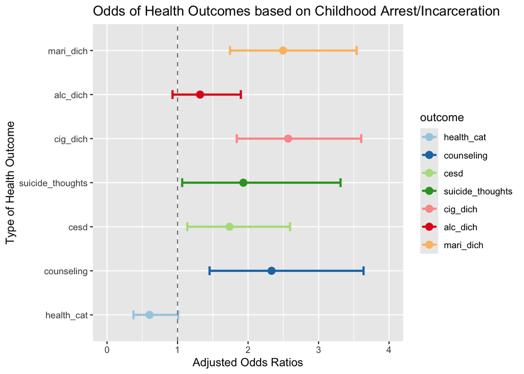

```r
adj_bon_OR$outcome <- factor(adj_bon_OR$outcome, levels = unique(adj_bon_OR$outcome))

forest_plot <- ggplot(data = adj_bon_OR, aes(x = odds_ratio, y = outcome, colour = outcome)) +
  geom_errorbarh(aes(xmin = lower_ci, xmax = upper_ci), height = 0.2, position = position_dodge(width = 0.5), size = 1) +
  geom_point(position = position_dodge(width = 0.5), size = 3, alpha = 1) +
  geom_vline(xintercept = 1, linetype = "dashed", color = "grey50", size = 0.5) +
  labs(title = "Odds of Health Outcomes based on Childhood Arrest/Incarceration",
    x = "Adjusted Odds Ratios", y = "Type of Health Outcome") +
  scale_color_brewer(palette = "Paired") +
  coord_cartesian(xlim = c(0, 4.0))
forest_plot
```

The forest plot above provides a visual representation of the resulting Bonferroni-corrected odds ratios from the adjusted regression models. It again displays that all outcomes of interest were found to be significantly associated with the exposure except for self-reported general health and alcohol usage.